# 02_question2

44

2022-06-01

# Q2 Carry out the steps of the statistical analysis outlined below.

Turn in **commented statistical code** used to obtain the results reported. Use no more than **3 decimal places**.

Lower-limb amputation (LLA) results primarily from complications of severe peripheral artery disease, diabetes mellitus, or trauma.

Sustained exercise has been suggested by previous studies as a promising rehabilitation target to improve the long-term health after LLA.

Using telehealth, a clinical trial has been conducted at the Veterans Affairs Eastern Colorado Regional Amputation Center to test the potential of sustaining walking exercise using **exercise self-management (EXP)** versus an **attention-control education (CTL)** program.

- The **primary outcome** is *step count per day*
- A few other **secondary outcomes** are also of interest including *presence of any adverse events*, as binary outcome.
- Outcomes were collected at **baseline (time=0)**, **6 months (time=6)** and **18 months (time=18)**.
- The primary hypothesis of the trial was that **the intervention would improve daily steps in at least 1000 steps**.
- Because randomization was **stratified by age ($< 60$ and $geq 60$)** and **level of amputation (below knee and above knee)**, these two variables should be adjusted for in the analyses.
- The longitudinal dataset of the study is in the table `data-lla.csv` with data dictionary below:
  - treat: `treat = EXP` for individuals in EXP group, and `treat = CTL` for individuals in CTL group
  - stepc: Step count
  - amp.above: amp.above=1 for amputation above the knee, amp.above=0 for amputation below the knee
  - time: Month from baseline
  - older: `older=1` for individuals 60 or older, and `older=0` for individuals younger than 60 years of age
- Use R or SAS to answer the following questions regarding the hypothesis above.

## Part 2a

The primary hypothesis of the study was to test **whether there was a difference of more than 1000 steps in the change of step count/day at 6 months between exposure groups**.

This particular type of trial is often referred to as a **superiority trial by a margin**. Carry out this hypothesis test and interpret your results for a clinical collaborator.

### i. Write the model formally in mathematical form. Allow for a difference in daily step count at baseline.

- $\beta_.$ are the parameters for generalized liear regression, $\beta_0$ is the intercept.

$$\begin{split}
& Y_{ij} | b_{i} \sim Poisson(\lambda)\\
& \eta_{ij} = log(E[Y_{ij}|b_{i}]) = log(\lambda | b_i) = X_{ij}
\beta + Z_{i} b_{i}\\
& = \beta_0 + \beta_1 \times treat_i + \beta_2 \times I(time6)_{ij}
+ \\
& \ \ \ \ \ \beta_3 \times I(time18)_{ij} + \beta_4 \times old_i +
\beta_5 \times amp_i + \\
& \ \ \ \ \ \beta_6 \times [treat::I(time6)] + \beta_7 \times
[treat::I(time18)] + Z_{i}b_{i}\\
& b_i \sim Normal (0, \sigma_b^2) \\
\end{split}$$

$$\begin{split}
& \pmb Y | \pmb b \sim Poisson(\lambda)\\
& \lambda | \pmb b = E(\pmb Y |\pmb b) \\
& \pmb V = Var(\pmb Y| \pmb b)\\
& \pmb \eta = \log (\lambda | \pmb b) = \pmb X \pmb \beta + \pmb Z
\pmb b\\
& \pmb b \sim Normal (\pmb 0, \pmb G)\
\end{split}$$

### ii. Write down the null and alternative hypothesis of interest in terms of the model parameters specified in (a); keep the terms consistent with (a).

Hull hypothesis: After adjusted for the other variables, there is no difference between LLA patients from the treatment group and control group, on *whether the change of step counts over 1000 at 6 month*.

$H_0$ :
$$e^{\beta_0 + \beta_1} (e^{\beta_2 + \beta_6} - 1)
- e^{\beta_0} (e^{\beta_2} - 1) \geq N$$

$N$ is the adjusted 1000 steps based on the information of age group and amputation location. For example, if the patient group is in `older==1` and `amput==1`, then $N = \frac {1000} {e^{\beta_4 + \beta_5}}$

Alternative hypothesis: After adjustment for baseline step counts and stratification on age and amputation location, treatment as a statistically significant effect on *whether the step counts over 1000 at 6 month* over control group.

$H_0$ :
$$exp^{\beta_0 + \beta_1} (exp ^ {\beta_2 +
\beta_6} - 1) - exp^{\beta_0} (exp ^ {\beta_2} - 1) < N$$

### iii. Calculate the change (from baseline) in expected means and standard error of the step counts at 6 months for each the intervention and the control group.

```r
## import dataset data_lla
data_lla <- read_csv("data/data-lla.csv",
                     col_types = cols(
                       ## amputation location as binary variable
                       amp.above = col_factor(levels = c("0", "1")),
                       ## older age or not as binary variable
                       older = col_factor(levels = c("0", "1"))))


data_lla_diff6 <- data_lla %>%
  ## change the from long format into wide format
  pivot_wider(names_from = "time",
              values_from = "stepc") %>%
  ## calculated the different from time0 to time6
  mutate(step_diff = abs(`6` - `0`)) %>%
  ## binary outcome of whether the change of step is over 1000
  mutate(step_diff_1k = case_when(step_diff >= 1000 ~ 1,
                                  step_diff < 1000 ~ 0),
         baseline = `0`)

# View(data_lla_diff6)
```

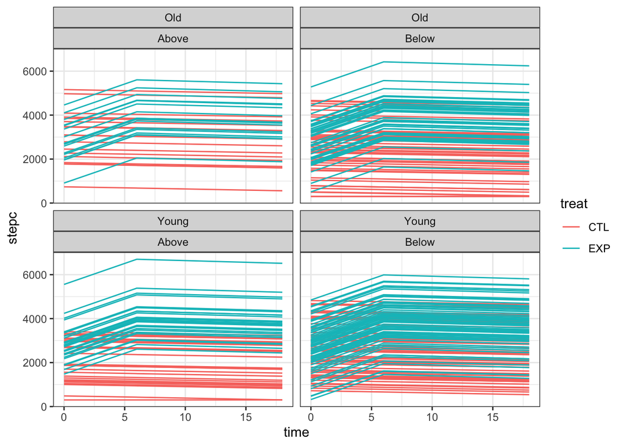

```r
plot_lla <- data_lla %>%
  mutate(older = case_when(older == 0 ~ "Young",
                           older == 1 ~ "Old"),
         amp.above = case_when(amp.above == 1 ~ "Above",
                               amp.above == 0 ~ "Below")) %>%
  ggplot(aes(x = time,
             y = stepc,
             group = id,
             color = treat)) +
  geom_line() +
  facet_wrap(older ~ amp.above)

plot_lla + theme_bw()
```

```r
data_lla_tf <- data_lla %>%
  mutate(time = as.factor(time))


fit_2_2 <- glmer(stepc ~ 1 + treat * time + older + amp.above +
                   + (1|id),
                 family = "poisson",
                 # control = fit_control,
                 data = data_lla_tf)
?glmer

## to get the coefficients
beta_2_2 <- (summary(fit_2_2)$coefficients[, 1]) %>% round(digits = 3)
beta_2_2
```

```
##     (Intercept)        treatEXP           time6          time18          older1
##           7.687           0.174          -0.023          -0.072           0.029
##      amp.above1  treatEXP:time6 treatEXP:time18
##          -0.005           0.372           0.372
```

```r
## to get the variance-covariance
vcov_2_2 <- vcov(fit_2_2) %>% round(digits = 3)
vcov_2_2
```

```
## 8 x 8 Matrix of class "dpoMatrix"
##                 (Intercept) treatEXP time6 time18 older1 amp.above1
## (Intercept)           0.002   -0.002     0      0 -0.001     -0.001
## treatEXP             -0.002    0.003     0      0  0.000      0.000
## time6                 0.000    0.000     0      0  0.000      0.000
## time18                0.000    0.000     0      0  0.000      0.000
## older1               -0.001    0.000     0      0  0.003      0.000
## amp.above1           -0.001    0.000     0      0  0.000      0.004
## treatEXP:time6        0.000    0.000     0      0  0.000      0.000
## treatEXP:time18       0.000    0.000     0      0  0.000      0.000
##                 treatEXP:time6 treatEXP:time18
## (Intercept)                  0               0
## treatEXP                     0               0
## time6                        0               0
## time18                       0               0
## older1                       0               0
## amp.above1                   0               0
## treatEXP:time6               0               0
## treatEXP:time18              0               0
```

```r
## using older and amputation below as reference group
##              [0]    [1]       [2]   [3]     [4]     [5]       [6]           [7]
## coefs        (Int)  treatEXP  time6 time18  older1  amp.abv1  trtEXP:time6  trtEXP:time18
con_trt_t0 <-   c(1,    1,        0,    0,      0,      0,        0,            0)
con_trt_t6 <-   c(1,    1,        1,    0,      0,      0,        1 * 1,        0)
##              c(0,    0,        1,    0,      0,      0,        1,            0)
con_trt_t6_t0 <- con_trt_t6 - con_trt_t0
con_trt_t18 <-  c(1,    1,        0,    1,      0,      0,        0,            1 * 1)

con_ctl_t0 <-   c(1,    0,        0,    0,      0,      0,        0,            0)
con_ctl_t6 <-   c(1,    0,        1,    0,      0,      0,        0,            0)
##              c(0,    0,        1,    0,      0,      0,        0,            0)
con_ctl_t6_t0 <- con_ctl_t6 - con_ctl_t0
con_ctl_t18 <-  c(1,    0,        0,    1,      0,      0,        0,            0)

contr2 <- cbind(con_trt_t6_t0, con_ctl_t6_t0)
rownames(contr2) <- rownames(vcov_2_2)
```

```r
mu_2_2 <- t(contr2) %*% beta_2_2 %>%
  as.data.frame() %>%
  dplyr::select("expected_mean" = 1)
## contrast variance covariance matrix
sd_2_2 <- t(contr2) %*% vcov_2_2 %*% contr2 %>%
  diag() %>% sqrt()

cbind(mu_2_2, "standard_error" = sd_2_2) %>%
  round(3)
```

```
##               expected_mean standard_error
## con_trt_t6_t0         0.349              0
## con_ctl_t6_t0        -0.023              0
```

### iv. Calculate the difference (EXP - CLT) in change of expected means in the two intervention groups. Report a 1-sided 95% confidence interval for this difference.

```r
con_tvc_t6_t0 <- con_trt_t6_t0 - con_ctl_t6_t0
mu_2_3 <- t(con_tvc_t6_t0 ) %*% beta_2_2 %>%
  as.data.frame() %>%
  dplyr::select("expected_mean" = 1)
## contrast variance covariance matrix
sd_2_3 <- t(con_tvc_t6_t0 ) %*% vcov_2_2 %*% con_tvc_t6_t0  %>%
  diag() %>% sqrt()

cbind(mu_2_3, "standard_error" = sd_2_3) %>%
  round(3)
```

```
##   expected_mean standard_error
## 1         0.372              0
```

```r
con_tvc_t0 <- con_trt_t0 - con_ctl_t0
con_tvc_t6 <- con_trt_t6 - con_ctl_t6
con_tvc_t18 <- con_trt_t18 - con_ctl_t18

contr3 <- cbind(con_tvc_t0, con_tvc_t6, con_tvc_t18)
rownames(contr3) <- rownames(vcov_2_2)
```

```r
mu_2_3 <- t(contr3) %*% beta_2_2 %>%
  as.data.frame() %>%
  dplyr::select("expected_mean" = 1)
## contrast variance covariance matrix
sd_2_3 <- t(contr3) %*% vcov_2_2 %*% contr3 %>%
  diag() %>% sqrt()

tbl_2_3 <- cbind(mu_2_3, "standard_error" = sd_2_3) %>%
  round(3)

map2(tbl_2_3$expected_mean,
     tbl_2_3$standard_error,
     ~ qnorm(0.95, mean = .x, sd = .y))
```

```
## [[1]]
## [1] 0.2644669
##
## [[2]]
## [1] 0.6364669
##
## [[3]]
## [1] 0.6364669
```

### v. Make a graph, and include any appropriate descriptive statistics, that you would present as evidence related to the primary hypothesis of interest.

#### using change score model

```r
fit_2_1 <- lm(step_diff ~ 1 + treat + older + amp.above,
               # control = fit_control,
               data = data_lla_diff6)

## to get the coefficients
beta_2_1 <- coef(fit_2_1) %>% round(digits = 3)
beta_2_1
```

```
## (Intercept)    treatEXP      older1  amp.above1
##      58.818    1081.156      -0.543       1.223
```

```r
## to get the variance-covariance
vcov_2_1 <- vcov(fit_2_1) %>% round(digits = 3)
vcov_2_1
```

```
##             (Intercept) treatEXP older1 amp.above1
## (Intercept)       0.551   -0.349 -0.316     -0.266
## treatEXP         -0.349    0.658  0.036      0.017
## older1           -0.316    0.036  0.680      0.048
## amp.above1       -0.266    0.017  0.048      0.778
```

```r
##                  [1]       [2]       [3]       [4]
## coefs           (Int)      treatEXP  old1      amp.above1
con_trt_old_abv <- c(1,        1,        1,        1)
con_trt_old_blw <- c(1,        1,        1,        0)
con_trt_yng_abv <- c(1,        1,        0,        1)
con_trt_yng_blw <- c(1,        1,        0,        0)

con_ctl_old_abv <- c(1,        0,        1,        1)
con_ctl_old_blw <- c(1,        0,        1,        0)
con_ctl_yng_abv <- c(1,        0,        0,        1)
con_ctl_yng_blw <- c(1,        0,        0,        0)


contr1 <- cbind(con_trt_old_abv,
                con_trt_old_blw,
                con_trt_yng_abv,
                con_trt_yng_blw,
                con_ctl_old_abv,
                con_ctl_old_blw,
                con_ctl_yng_abv,
                con_ctl_yng_blw)
rownames(contr1) <- rownames(vcov_2_1)
```

```r
mu_2_1 <- t(contr1) %*% beta_2_1 %>%
  as.data.frame() %>%
  dplyr::select("expected_mean" = 1)
## contrast variance covariance matrix
sd_2_1 <- t(contr1) %*% vcov_2_1 %*% contr1 %>%
  diag() %>% sqrt()

cbind(mu_2_1, "standard_error" = sd_2_1) %>%
  round(3)
```

```
##                 expected_mean standard_error
## con_trt_old_abv      1140.654          1.003
## con_trt_old_blw      1139.431          0.794
## con_trt_yng_abv      1141.197          0.889
## con_trt_yng_blw      1139.974          0.715
## con_ctl_old_abv        59.498          0.970
## con_ctl_old_blw        58.275          0.774
## con_ctl_yng_abv        60.041          0.893
## con_ctl_yng_blw        58.818          0.742
```